# Priors, P-values, and Pfizer: Reanalyzing the BNT162b2 Vaccine Efficacy Trial

Joe Clair, Jay Kumar, and Andrew Tang

March 10, 2026

# Abstract

# Keywords

*Vaccine Efficacy*, *COVID-19*, *Prior Elicitation*, *Bayesian Analysis*

# Introduction / Background

The COVID-19 pandemic, caused by SARS-CoV-2, was one of the most disruptive global health crises in modern history. The pandemic impacted global health substantially by not only claiming an estimated 7.1 million lives worldwide (WHO, 2022), but also triggering widespread economic disruption and social issues, including school closures and lockdowns across the globe.

To evaluate vaccine efficacy, each company who developed a vaccine employed statistical methods to analyze their data. Pfizer used a Bayesian beta-binomial model and reported 95% efficacy (Polack et al., 2020), while another company, Moderna, modeled their data using a frequentist approach on a similar mRNA vaccine and reported 94.1% efficacy (Baden et al., 2021). The fact that two different statistical frameworks applied to similar mRNA vaccines had similar conclusions was promising, suggesting the high efficacy of this mRNA holds strong no matter the statistical framework. However, Pfizer’s Bayesian analysis did not go without scrutiny. Senn (2021) argues that their prior distribution was reverse-engineered from the FDA’s 30% threshold rather than reflecting genuine pre-trial belief. We therefore independently reanalyze the Pfizer trial data using both Bayesian and frequentist methods, this time using a prior that is more in line with the Bayesian framework of eliciting our prior beliefs. After our test is done, we will see if the same conclusions hold. Specifically, we test:

$$H_0: \psi = 0.30 \quad \text{vs} \quad
H_1: \psi > 0.30$$

# Statistical Methods

## Model

The parameter of interest for this study is,

$$1 - \frac{ \hat \pi_v}{ \hat
\pi_p}$$
This gives us the efficacy of the vaccine against Covid-19, where $\hat \pi_v$ is the probability of Covid-19 with the vaccine and $\hat \pi_p$ is the probability of Covid-19 with the placebo.

Suppose we define the random variable T as the number in the Vaccine group from the n = 170 Covid-19 cases

The distribution of T can be estimated by a binomial distribution which is proved in the appendix

Then,

$$T \sim Binom(n = 170, \pi)$$
Where $\pi$ = P(vaccine | Covid 19 Case) which is equal to,

$$\pi = \frac{n_1\pi_v}{n_1\pi_v +
n_2\pi_p}$$
Since $n_1 \approx n_2$, $\pi$ becomes,
$$\pi = \frac{\pi_v}{\pi_v + \pi_p}$$
Our parameter of interest is the efficacy which as defined is,
$$\psi = 1 - \frac{ \pi_v}{ \pi_p} = \frac{\pi_v
-\pi_p }{\pi_p}$$
When can represent this in terms of our binomial probability $\pi$ as,

$$\psi = \frac{1 - 2\pi}{1 - \pi}$$
Since the FDA requires at least a 30% efficacy for the vaccine to be approved our hypothesis that we will test will be,

$H_o : \psi = 0.3$ versus $H_1 : \psi > 0.3$

## Likelihood Inference

We will calculate the parameter $\psi$ using the likelihood estimator and since $T \sim Binom(n = 170, \pi)$ the Likelihood function in terms of $\pi$ will be,

$$L(\pi) = \binom{n}{k}\pi^k(1-\pi)^{n -
k} =\binom{170}{8}\pi^8(1-\pi)^{162}$$
We solve this to find the MLE of $\pi$ and since MLEs are invariant to transformation we can solve for $\psi$.

We can represent $\psi$ with $\pi$ as the following,
$$\pi = \frac{1 - \psi}{2 - \psi}$$

To calculate the confidence interval for our estimate, we can use the theorem that our estimate is normally distributed with $\psi_0$ as the mean and the standard error as $\frac{1}{\sqrt{I(\psi_0)}}$, where $I(\psi_0)$ is the expected fisher information. To show that n is large enough and that regularity condition holds for this theorem to be used we need to verify that the log-likelihood function can be well approximated by a second order Taylor series around the MLE.

[figure not shown]

The fisher expected fisher information is given by,

$$I(\psi_0) =
E[-\frac{d^2}{d\psi^2}l^*(\psi)]_{\psi = \psi_0}$$
We can calculate a 95% confidence interval with,
$$\hat \psi^{mle} \pm
z_{\alpha/2}\sqrt{\frac{1}{I(\hat \psi^{mle})}}$$

We will also calculate the interval through a parametric bootstrap percentile interval.

To do this we will follow the steps of first repeatedly creating new samples from the distribution,
$$T \sim
Binom(n = 170, \hat \pi)$$
We re-sample from the binomial distribution using our estimated $\pi$ from the original sample of the trials. Then with each sample we will calculate our estimate $\psi$ and then for the 95% confidence interval will take the 2.5th and 97.5th percentile to create our confidence interval.

To assess whether the data provide sufficient evidence against $H_0$, we use the likelihood ratio test statistic,

$$W = 2[\ell^*(\hat{\psi}^{mle}) -
\ell^*(\psi_0)]$$
which measures how much more likely the observed data are under the MLE compared to the null value $\psi_0 = 0.3$. Large values of $W$ indicate the null hypothesis is not likely given the data. Under $H_0$, $W$ follows an approximate $\chi^2_1$ distribution for large $n$, which we use to compute a P-value. We also compute an empirical P-value by simulating the distribution of $W$ under $H_0$ directly.

## Bayesian Inference

Before seeing the data, we set two prior beliefs about vaccine efficacy $\psi$. We chose $P(\psi \geq 0.3) = 0.10$ because mRNA vaccines had never been approved before, and most Phase 3 vaccine trials fail, so we were skeptical the vaccine would clear the FDA’s 30% bar. We chose $P(\psi \geq 0) = 0.60$ given promising immune responses observed in Phase 1/2 trials (Polack et al., 2020). Following Senn (2021), who argues Pfizer’s prior was reverse-engineered from the FDA threshold rather than reflecting real prior beliefs, we created our beliefs directly rather than working backwards from the approval standard. We now will use the `beta.select` function in R in order to generate a beta distribution from our new prior beliefs.

Under our prior beliefs,
$$\begin{align*}
P (\psi \geq 0.3) = 0.1, \ \ \ P (\psi \geq 0) = 0.6.
\end{align*}$$

When $\psi = 0.3$,
$$\begin{align*}
\pi = \frac{1-0.3}{2-0.3} = \frac{0.7}{1.7} = \frac{7}{17}.
\end{align*}$$
Thus,
$$\begin{align*}
P(\psi \geq 0.3) = 0.1
\quad \Longleftrightarrow \quad
P\left(\pi \leq \frac{7}{17}\right) = 0.1.
\end{align*}$$

When $\psi = 0$,
$$\begin{align*}
\pi = \frac{1-0}{2-0} = \frac{1}{2}.
\end{align*}$$
Thus,
$$\begin{align*}
P(\psi \geq 0) = 0.6
\quad \Longleftrightarrow \quad
P\left(\pi \leq \frac{1}{2}\right) = 0.6.
\end{align*}$$

So, our conditions for $\pi$ are
$$\begin{align*}
P\left(\pi \leq \frac{7}{17}\right) = 0.1,
\qquad
P\left(\pi \leq \frac{1}{2}\right) = 0.6.
\end{align*}$$

Using this to create a beta distribution gives $Beta (36.40, 38.58)$ as the prior.

```r
library(LearnBayes)
beta.select(
  quantile1 = list(p = 0.10, x = 7/17),
  quantile2 = list(p = 0.60, x = 0.50)
)
```

```
## [1] 36.40 38.58
```

Because the Beta distribution is conjugate to the Binomial, the posterior distribution of $\pi$ is also a Beta distribution.
$$T \mid \pi \sim \text{Binomial}(n,\pi)$$
and
$$\pi \sim \text{Beta}(a,b),$$
then the posterior distribution is
$$\pi \mid T=t \sim \text{Beta}(a+t,\; b+n-t).$$
For our data, $n=170$ and $t=8$, so the posterior distribution is
$$\pi \mid T=8 \sim \text{Beta}(a+8,\; b+162).$$

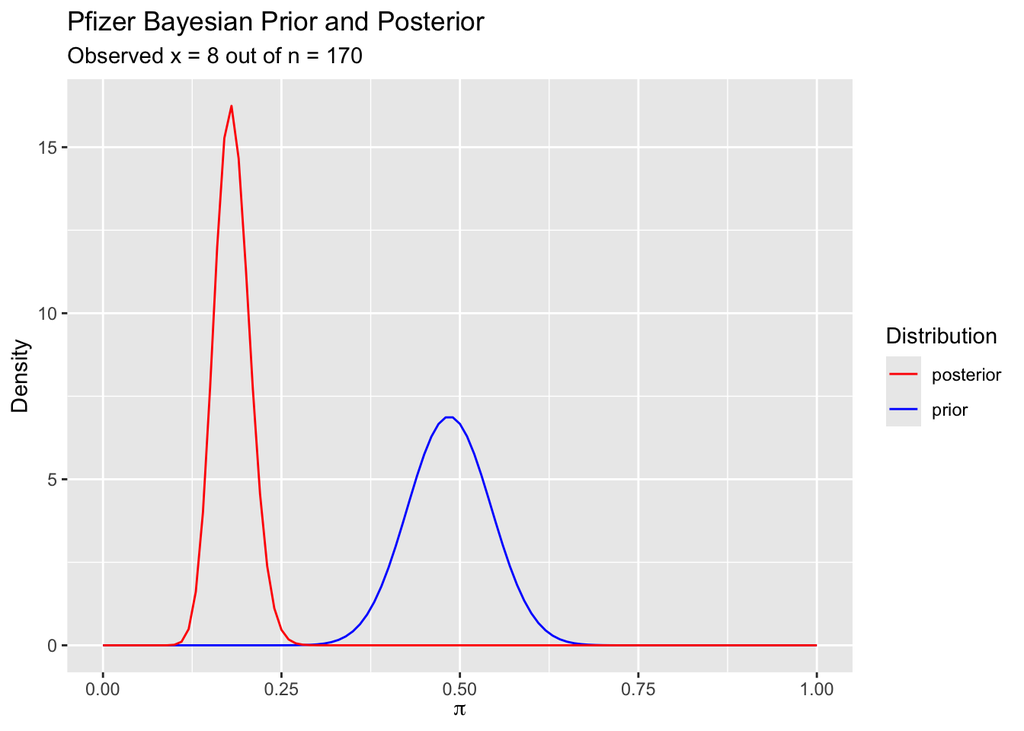

To convert the posterior summaries from $\pi$ to $\psi$, we use
$$\psi = \frac{1-2\pi}{1-\pi}.$$

Using the posterior median of $\pi$, we have
$$\psi_{\text{median}}
= \frac{1 - 2(0.180371)}{1 - 0.180371}
= \frac{1 - 0.360742}{0.819629}
= \frac{0.639258}{0.819629}
= 0.779936.$$

For the 95% equal-tail interval, we transform each endpoint separately:
$$\psi_{\text{lower}}
= \frac{1 - 2(0.2317538)}{1 - 0.2317538}
= \frac{1 - 0.4635076}{0.7682462}
= \frac{0.5364924}{0.7682462}
= 0.698334,$$
and
$$\psi_{\text{upper}}
= \frac{1 - 2(0.1356515)}{1 - 0.1356515}
= \frac{1 - 0.2713030}{0.8643485}
= \frac{0.7286970}{0.8643485}
= 0.843059.$$

Similarly, transforming the HPDI endpoints gives
$$\psi_{\text{lower}}
= \frac{1 - 2(0.2299012)}{1 - 0.2299012}
= 0.701465,
\qquad
\psi_{\text{upper}}
= \frac{1 - 2(0.1340409)}{1 - 0.1340409}
= 0.845211.$$

# Results

The parametric bootstrap estimates the interval as, (0.9102564, 0.9820359 )

## Hypothesis test findings

Both hypothesis tests provided overwhelming evidence against $H_0: \psi = 0.30$. The likelihood ratio test statistic was $W = 121.6012$, which under the $\chi^2_1$ approximation yields a P-value essentially equal to zero. The empirical P-value, obtained by simulating 10,000 samples from the null distribution of $T \sim Binom(170, \pi_0)$ where $\pi_0 = 7/17$, was similarly $p_{emp} = 0$. Both results provide evidence that the true vaccine efficacy exceeds the FDA minimum threshold of 30%.

## Bayesian

The posterior probability $P \left( \psi \leq 0.3 \mid t \right)$ corresponds to $P \left(\pi \geq \frac{0.7}{1.7} \mid t \right)$ which is $4.367864e-15$.

# Discussion / Conclusion

# Bibliography

Baden, L. R., El Sahly, H. M., Essink, B., Kotloff, K., Frey, S., Novak, R., … & Zaks, T. (2021). Efficacy and safety of the mRNA-1273 SARS-CoV-2 vaccine. *New England Journal of Medicine*, 384(5), 403–416.

Polack, F. P., Thomas, S. J., Kitchin, N., Absalon, J., Gurtman, A., Lockhart, S., … & Jansen, K. U. (2020). Safety and efficacy of the BNT162b2 mRNA Covid-19 vaccine. *New England Journal of Medicine*, 383(27), 2603–2615.

Senn, S. (2021). *Beta testing: The Pfizer/BioNTech statistical analysis of their Covid-19 vaccine trial*. Error Statistics Philosophy. Retrieved from https://errorstatistics.com/2021/01/17/s-senn-beta-testing-the-pfizer-biontech-statistical-analysis-of-their-covid-19-vaccine-trial-guest-post/

World Health Organization. (2022). *COVID-19 dashboard*. Retrieved from https://data.who.int/dashboards/covid19/deaths?n=c

# Appendix

## Code

```r
# You can reference your code in the appendix (sample here).
```

```r
#Calculating W and then Chi Sq approximation P-value
n <- 170
t <- 8
psi_hat <- (n - 2*t) / (n - t)
psi_0 <- 0.3

loglik.psi <- function(psi, t, n) {
  t * log(1 - psi) - n * log(2 - psi)
}

W_obs <- 2 * (loglik.psi(psi_hat, t, n) - loglik.psi(psi_0, t, n))
W_obs
```

```
## [1] 121.6012
```

```r
1 - pchisq(W_obs, df = 1)
```

```
## [1] 0
```

```r
#Empirical P-value calcuation
set.seed(342)
B <- 10000
n <- 170
psi_0 <- 0.3
pi_0 <- (1 - psi_0) / (2 - psi_0)  # null value of pi

w_star <- replicate(B, {
  t_star <- rbinom(1, size = n, prob = pi_0)
  psi_hat_star <- (n - 2*t_star) / (n - t_star)
  2 * (loglik.psi(psi_hat_star, t_star, n) - loglik.psi(psi_0, t_star, n))
})

p_emp <- mean(w_star >= W_obs)
p_emp
```

```
## [1] 0
```

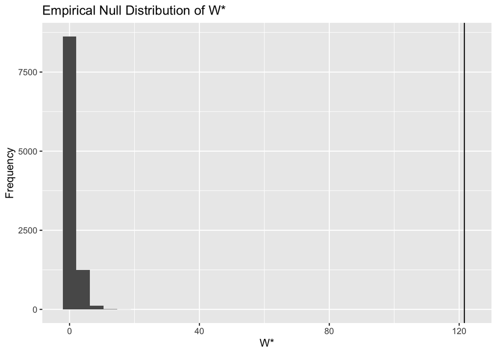

```r
df <- data.frame(w_star = w_star)
ggplot(df, aes(x = w_star)) +
  geom_histogram() +
  geom_vline(xintercept = W_obs) +
  labs(
    title = "Empirical Null Distribution of W*",
    x = "W*",
    y = "Frequency"
  )
```

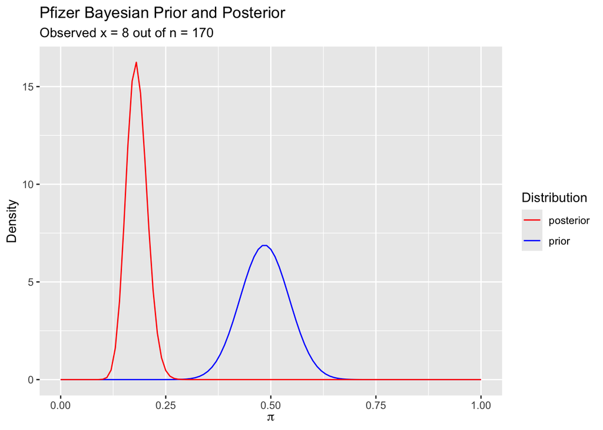

```r
#Prior and Posterior graph
x <- 8
n <- 170
a <- 36.40
b <- 38.58

ggplot() +
  geom_function(
    fun = dbeta,
    mapping = aes(color = "prior"),
    args = list(shape1 = a, shape2 = b),
    xlim = c(0, 1)
  ) +
  geom_function(
    fun = dbeta,
    mapping = aes(color = "posterior"),
    args = list(shape1 = a + x, shape2 = b + n - x),
    xlim = c(0, 1)
  ) +
  scale_color_manual(name = "Distribution", values = c("prior" = "blue", "posterior" = "red")) +
  labs(
    title = "Pfizer Bayesian Prior and Posterior",
    subtitle = "Observed x = 8 out of n = 170",
    x = expression(pi),
    y = "Density"
  )
```

```r
#Posterior Summary calculation
qbeta(0.5, shape1 = 36.40 + 8, shape2 = 38.58 + 170 - 8)
```

```
## [1] 0.180371
```

```r
qbeta(p = c(0.025, 0.975), shape1 = 36.40 + 8, shape2 = 38.58 + 170 - 8)
```

```
## [1] 0.1356515 0.2317538
```

```r
hdi(qbeta, credMass = 0.95, shape1 = 36.40 + 8, shape2 = 38.58 + 170 - 8)
```

```
##     lower     upper
## 0.1340409 0.2299012
## attr(,"credMass")
## [1] 0.95
```

```r
#Bayesian P value
pbeta(0.7/1.7, shape1 = 44.40, shape2 = 200.58, lower.tail = FALSE)
```

```
## [1] 4.367864e-15
```

```r
#Bootstrap CI
set.seed(342)

n <- 170
v <- 8
pi_hat <- v/n
psi_hat <- (n - 2*v)/(n - v)

B <- 10000

t <- rbinom(n = B, size = n, prob = pi_hat)

psi <- (n - 2*t) / (n - t)

c(lower = quantile(psi, 0.025),upper = quantile(psi, 0.975))
```

```
##  lower.2.5% upper.97.5%
##   0.9102564   0.9820359
```

```r
#Fisher Information CI
n <- 170
v <- 8
psi_hat <- (n - 2*v) / (n - v)

I <- 8/(1 - psi_hat)^2 + 170/(2 - psi_hat)^2

SE <- 1/sqrt(I)

lower <- psi_hat - 1.96 * SE
upper <- psi_hat + 1.96 * SE
c(lower,upper)
```

```
## [1] 0.9171746 0.9840599
```

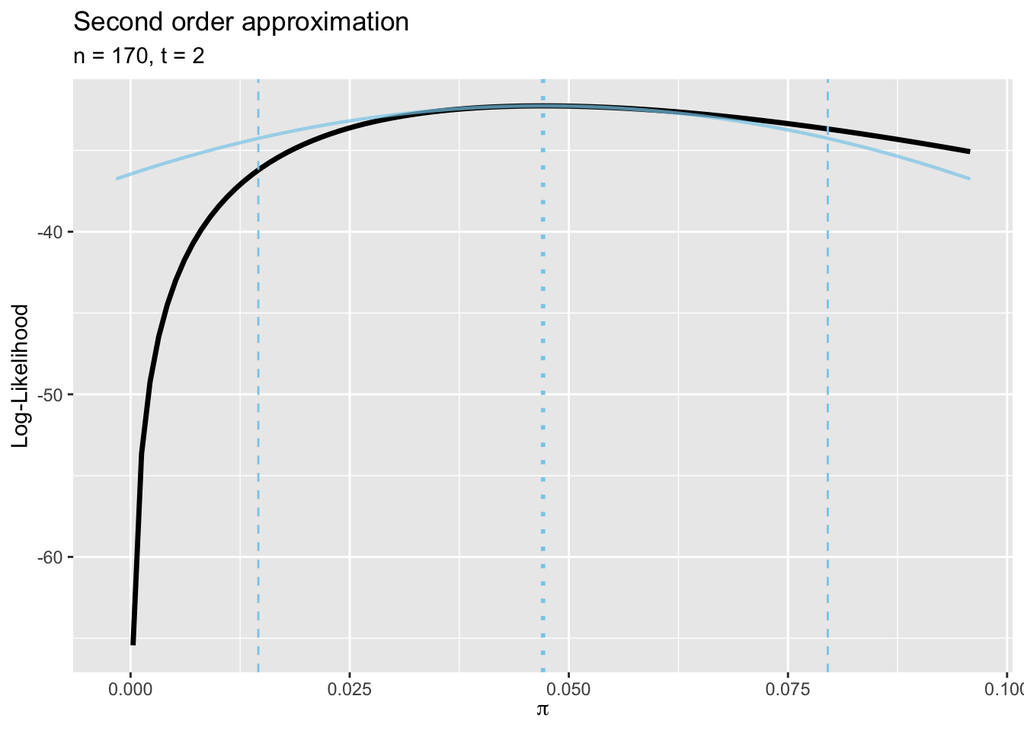

```r
#Second order approximation
loglik.pi <- function(pi, v, n) {
  ifelse((pi <= 0 | pi >= 1), NA,
    v * log(pi) + (n - v) * log(1 - pi)
  )
}

ml.pi <- maxLik2(loglik = loglik.pi,
                 start = 0.5,
                 v = 8,
                 n = 170)

plot(ml.pi) +
  labs(title = "Second order approximation",
       subtitle = "n = 170, t = 2",
       x = expression(pi),
       y = "Log-Likelihood")
```

#Proofs and Working

To simply our estimator $\pi$ we have by definition of conditional probability,
$$\pi = P(Vaccine | Covid19) =\frac{ P(Vaccine)
\land P(Covid19)}{P(Covid19)}$$
$$=\frac{ P(Vaccine) P(Covid19 |
Vaccine)}{P(Vaccine)P(Covid19 | vaccine) + P(placebo)P(Covid19 |
placebo)}$$

$$= \frac{\frac{n1}{n1 +
n2}\pi}{\frac{n_1 \pi_v + n_2 \pi_p}{n_1 + n_2}}$$
$$= \frac{n_1 \pi_v}{n_1 \pi_v + n_2
\pi_p}$$

To calculate the MLE we do the following,
$$L(\pi) = \binom{n}{k}\pi^k(1-\pi)^{n - k}
=\binom{170}{8}\pi^8(1-\pi)^{162}$$
$$L^*(\psi) =\binom{170}{8}(\frac{1 - \psi}{2 -
\psi})^8(1-\frac{1 - \psi}{2 - \psi})^{162}$$
$$l^*(\psi) =log(\binom{170}{8}) + 8log(1 - \psi)
- 8log(2 - \psi) +162log(1-\frac{1 - \psi}{2 - \psi})$$
$$=log(\binom{170}{8}) + 8log(1 - \psi) - 8log(2 -
\psi) +162log(\frac{1 }{2 - \psi})$$
$$=log(\binom{170}{8}) + 8log(1 - \psi) - 8log(2 -
\psi) +162log(1) - 162log(2 - \psi)$$
$$l^{*'}(\psi) = -\frac{8}{1 - \psi} +
\frac{170}{2 - \psi}$$
$$-\frac{8}{1
- \psi} + \frac{170}{2 - \psi} = 0$$
$$\frac{170}{2 - \psi} = \frac{8}{1 -
\psi}$$
$$170 - 170\psi = 16 -
8\psi$$
$$154 = 162\psi$$
$$\hat \psi^{mle} = \frac{154}{162} =
0.95061$$
We will now calculate the interval using this distribution of our estimate, The fisher expected fisher information is given by,
$$I(\psi_0) =
E[-\frac{d^2}{d\psi^2}l^*(\psi)]_{\psi = \psi_0}$$
$$-\frac{d^2}{d\psi^2}l^*(\psi) = \frac{8}{1 -
\psi} + \frac{170}{(2 - \psi)^2}$$
$$E[-\frac{d^2}{d\psi^2}l^*(\psi)]_{\psi = \psi_0}
= \frac{8}{1 - \psi} + \frac{170}{(2 - \psi)^2}$$
$$= \frac{8}{1 - \frac{154}{162}} + \frac{170}{(2
- \frac{154}{162})^2}$$
$$=
\frac{13122}{85}$$
We can calculate a 95% confidence interval with,
$$\hat \psi^{mle} \pm
z_{\alpha/2}\sqrt{\frac{1}{I(\hat \psi^{mle})}}$$

To represent $\psi$ in terms of $\pi$,
$$\psi = \frac{1 - 2\pi}{1 - \pi}$$
$$(1 - \pi)\psi = 1 - 2\pi$$
$$2\pi- \pi\psi = 1 - \psi$$
$$\pi(2 - \psi) = 1 - \psi$$
$$\pi = \frac{1 - \psi}{2 - \psi}$$